# Uber Data Science Challenge

```r
uber_df <- read_csv('/Users/nguyenhalinh/Desktop/Github/UberDataScienceChallenge/datasets/ds_challenge_v2_1_data.csv',
                    show_col_types = FALSE)
```

```r
head(uber_df)
```

| id | city_name | signup_os | signup_channel | signup_date | bgc_date | vehicle_added_date | vehicle_make | vehicle_model | vehicle_year | first_completed_date |
| --- | --- | --- | --- | --- | --- | --- | --- | --- | --- | --- |
| 1 | Strark | ios web | Paid | 1/2/16 | NA | NA | NA | NA | NA | NA |
| 2 | Strark | windows | Paid | 1/21/16 | NA | NA | NA | NA | NA | NA |
| 3 | Wrouver | windows | Organic | 1/11/16 | 1/11/16 | NA | NA | NA | NA | NA |
| 4 | Berton | android web | Referral | 1/29/16 | 2/3/16 | 2/3/16 | Toyota | Corolla | 2016 | 2/3/16 |
| 5 | Strark | android web | Referral | 1/10/16 | 1/25/16 | 1/26/16 | Hyundai | Sonata | 2016 | NA |
| 6 | Strark | android web | Referral | 1/18/16 | 1/18/16 | 1/22/16 | Cadillac | DTS | 2006 | NA |

## **Data Manipulation**

#### **Driver Signup Criteria**:

1. **Sucessful Signup**: Drivers who finished background check, added vehicle and starting their first trip
2. **In-Progress**: Drivers who completed signing up, background check and added vehicle, but haven’t started driving
3. **Wait-and-See**: Drivers who just finished initial signing up, but didn’t go through background check or didn’t add vehicle

```r
## show data dimension
dim(uber_df)
```

```
[1] 54681    11
```

```r
# Data Types
sapply(uber_df,typeof)
```

```
                  id            city_name            signup_os       signup_channel          signup_date
            "double"          "character"          "character"          "character"          "character"
            bgc_date   vehicle_added_date         vehicle_make        vehicle_model         vehicle_year
         "character"          "character"          "character"          "character"             "double"
first_completed_date
         "character"
```

```r
# Counting unique values in each column
sapply(uber_df, function(x) length(unique(x)))
```

```
                  id            city_name            signup_os       signup_channel          signup_date
               54681                    3                    6                    3                   30
            bgc_date   vehicle_added_date         vehicle_make        vehicle_model         vehicle_year
                  75                   79                   47                  369                   25
first_completed_date
                  58
```

```r
# count missing values
colSums(is.na(uber_df))
```

```
                  id            city_name            signup_os       signup_channel          signup_date
                   0                    0                 6857                    0                    0
            bgc_date   vehicle_added_date         vehicle_make        vehicle_model         vehicle_year
               21785                41547                41458                41458                41458
first_completed_date
               48544
```

According to Uber’s Privacy Policy, consent to a background check is required for driver partners where permitted by law. Therefore, we can disregard all signups that is missing a background check date.

There is a general rule that I like to follow that pertains to handling missing data: if a feature has more than 60% of its values missing, I discard the feature. If I choose to fill those missing values, I will be assumming 60% of the data. This can have an effect on the confidence of the model and the overall analysis of this specific task. However, if I wanted to do analysis pertaining to that specific feature, then I would use imputation methods such as mean or median to fill in the missing values.

- A feature that represents if someone took their first drive or not
- A feature that represents the time difference between when a person signs up and when they submit their background check consent form
- A feature that represents the time difference between when a person submits their background check consent form and when they add their vehicle
- A feature that represents the time difference between when a person adds their vehicle and when they complete their first drive
- A feature that represents the time difference between when a person signs up and when they complete their first drive

```r
# Drop missing values in bgc_date column
uber_df <- uber_df[!is.na(uber_df$bgc_date), ]
```

```r
# Create Target column (Whether the driver completed first drive or not)
uber_df$is_completed <- ifelse(is.na(uber_df$first_completed_date), 0, 1)
```

```r
head(uber_df)
```

| id | city_name | signup_os | signup_channel | signup_date | bgc_date | vehicle_added_date | vehicle_make | vehicle_model | vehicle_year | first_completed_date | is_completed |
| --- | --- | --- | --- | --- | --- | --- | --- | --- | --- | --- | --- |
| 3 | Wrouver | windows | Organic | 1/11/16 | 1/11/16 | NA | NA | NA | NA | NA | 0 |
| 4 | Berton | android web | Referral | 1/29/16 | 2/3/16 | 2/3/16 | Toyota | Corolla | 2016 | 2/3/16 | 1 |
| 5 | Strark | android web | Referral | 1/10/16 | 1/25/16 | 1/26/16 | Hyundai | Sonata | 2016 | NA | 0 |
| 6 | Strark | android web | Referral | 1/18/16 | 1/18/16 | 1/22/16 | Cadillac | DTS | 2006 | NA | 0 |
| 7 | Strark | ios web | Paid | 1/14/16 | 1/16/16 | 1/21/16 | Toyota | Prius V | 2014 | 1/23/16 | 1 |
| 8 | Strark | ios web | Referral | 1/26/16 | 2/5/16 | NA | NA | NA | NA | NA | 0 |

```r
# Convert date columns to date type
# Specify the date columns to convert
date_columns <- c("signup_date", "bgc_date", "vehicle_added_date", "first_completed_date")

# Convert multiple date columns to datetime type
uber_df[date_columns] <- lapply(uber_df[date_columns], as.Date, format = "%m/%d/%Y")
```

```r
# Data Types
sapply(uber_df,typeof)
```

```
                  id            city_name            signup_os       signup_channel          signup_date
            "double"          "character"          "character"          "character"             "double"
            bgc_date   vehicle_added_date         vehicle_make        vehicle_model         vehicle_year
            "double"             "double"          "character"          "character"             "double"
first_completed_date         is_completed
            "double"             "double"
```

```r
# Calculate the number of days difference from signup to complete first ride
uber_df$signup_to_completed = uber_df$first_completed_date - uber_df$signup_date

# Calculate the number of days difference from signup to background check
uber_df$signup_to_bgc = uber_df$bgc_date - uber_df$signup_date

# Calculate the number of days difference from background check to vehicle added information date
uber_df$bgc_to_vehicle = uber_df$vehicle_added_date - uber_df$bgc_date

# Calculate the number of days difference from vehicle added date to complete first ride
uber_df$vehicle_to_completed = uber_df$first_completed_date - uber_df$bgc_date
```

```r
head(uber_df)
```

| id | city_name | signup_os | signup_channel | signup_date | bgc_date | vehicle_added_date | vehicle_make | vehicle_model | vehicle_year | first_completed_date | is_completed | signup_to_completed | signup_to_bgc | bgc_to_vehicle | vehicle_to_completed |
| --- | --- | --- | --- | --- | --- | --- | --- | --- | --- | --- | --- | --- | --- | --- | --- |
| 3 | Wrouver | windows | Organic | 0016-01-11 | 0016-01-11 |  | NA | NA | NA |  | 0 | NA days | 0 days | NA days | NA days |
| 4 | Berton | android web | Referral | 0016-01-29 | 0016-02-03 | 0016-02-03 | Toyota | Corolla | 2016 | 0016-02-03 | 1 | 5 days | 5 days | 0 days | 0 days |
| 5 | Strark | android web | Referral | 0016-01-10 | 0016-01-25 | 0016-01-26 | Hyundai | Sonata | 2016 |  | 0 | NA days | 15 days | 1 days | NA days |
| 6 | Strark | android web | Referral | 0016-01-18 | 0016-01-18 | 0016-01-22 | Cadillac | DTS | 2006 |  | 0 | NA days | 0 days | 4 days | NA days |
| 7 | Strark | ios web | Paid | 0016-01-14 | 0016-01-16 | 0016-01-21 | Toyota | Prius V | 2014 | 0016-01-23 | 1 | 9 days | 2 days | 5 days | 7 days |
| 8 | Strark | ios web | Referral | 0016-01-26 | 0016-02-05 |  | NA | NA | NA |  | 0 | NA days | 10 days | NA days | NA days |

# **Exploratory Data Analysis**

### **Which city attracts the most new drivers signing up ?**

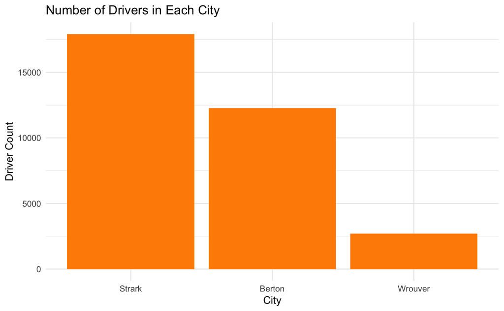

```r
# Count the number of drivers in each city
driver_counts <- table(uber_df$city_name)

# Convert the driver counts to a data frame
driver_counts_df <- as.data.frame(driver_counts)

# Rename the columns in the driver counts data frame
names(driver_counts_df) <- c("City", "Driver_Count")

# Sort the data in descending order
driver_counts_df <- driver_counts_df[order(driver_counts_df$Driver_Count, decreasing = TRUE), ]

# Create a bar graph
ggplot(driver_counts_df, aes(x = factor(City, levels = City), y = Driver_Count)) +
  geom_bar(stat = "identity", fill = "darkorange") +
  labs(title = "Number of Drivers in Each City", x = "City", y = "Driver Count") +
  theme_minimal()
```

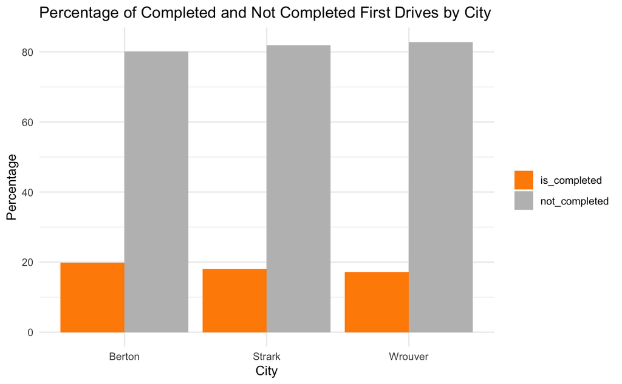

```r
# Group the data frame by 'city_name' and 'is_completed' and calculate the percentages
grouped <- aggregate(is_completed ~ city_name, data = uber_df, FUN = function(x) sum(x) / length(x) * 100)
grouped$not_completed <- 100 - grouped$is_completed

# Convert the data to long format
grouped_long <- tidyr::gather(grouped, key = Status, value = Percentage, is_completed, not_completed)
grouped_long$Status <- factor(grouped_long$Status, levels = c("is_completed", "not_completed"))

# Create the grouped bar chart
ggplot(grouped_long, aes(x = city_name, y = Percentage, fill = Status)) +
  geom_bar(stat = "identity", position = "dodge") +
  labs(title = "Percentage of Completed and Not Completed First Drives by City", x = "City", y = "Percentage") +
  scale_fill_manual(values = c("is_completed" = "darkorange", "not_completed" = "gray")) +
  theme_minimal() +
  theme(legend.title = element_blank())
```

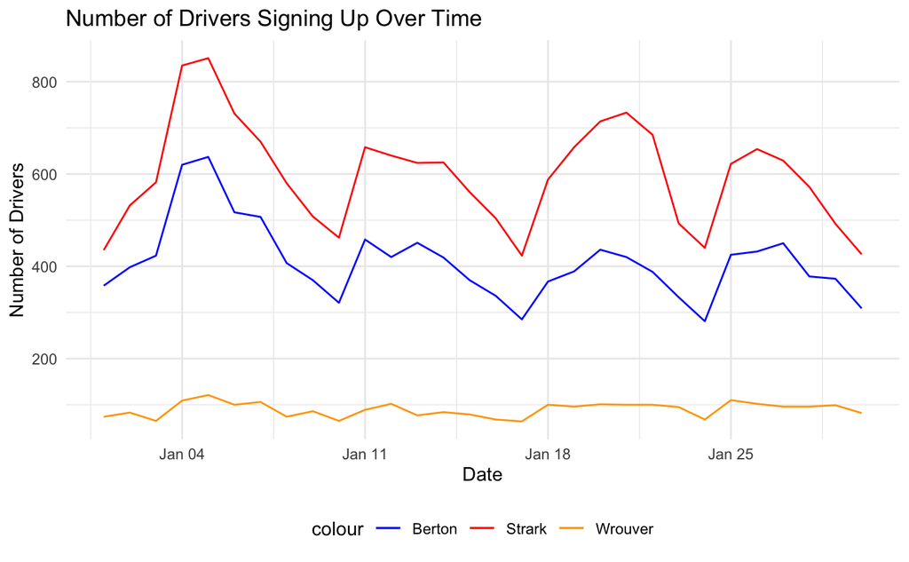

```r
# Group by 'City' and count the number of drivers signing up on each date
grouped <- uber_df %>%
  group_by(city_name, signup_date) %>%
  summarise(Count = n())
# Pivot the DataFrame to have cities as columns and dates as the index
df_pivot <- pivot_wider(grouped, names_from = city_name, values_from = Count, names_sort = TRUE)

# Plot the line chart
ggplot(df_pivot, aes(x = signup_date)) +
  geom_line(aes(y = Berton, color = "Berton")) +
  geom_line(aes(y = Strark, color = "Strark")) +
  geom_line(aes(y = Wrouver, color = "Wrouver")) +
  # Add more geom_line() statements for additional cities if needed
  labs(title = "Number of Drivers Signing Up Over Time", x = "Date", y = "Number of Drivers") +
  theme_minimal() +
  theme(legend.position = "bottom") +
  scale_color_manual(values = c("blue", "red", "orange"))  # Specify colors for each city
```

- Most drivers signing up are from Strark but Berton has slightly more percentage of signed up drivers that officially become Uber drivers
- Strark and Berton have the same trend of the number of drivers signing up

### **Which sign-up channel brings us the most drivers?**

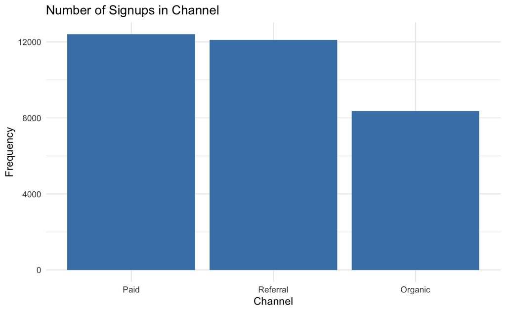

```r
# Count the number of signups through each channel
channel_counts <- table(uber_df$signup_channel)

# Convert the channel counts to a data frame
channel_counts_df <- as.data.frame(channel_counts)

# Rename the columns in the driver counts data frame
names(channel_counts_df) <- c("Channel", "Frequency")

# Sort the data in descending order
channel_counts_df <- channel_counts_df[order(channel_counts_df$Frequency, decreasing = TRUE), ]

# Create a bar graph
ggplot(channel_counts_df, aes(x = factor(Channel, levels = Channel), y = Frequency)) +
  geom_bar(stat = "identity", fill = "steelblue") +
  labs(title = "Number of Signups in Channel", x = "Channel", y = "Frequency") +
  theme_minimal()
```

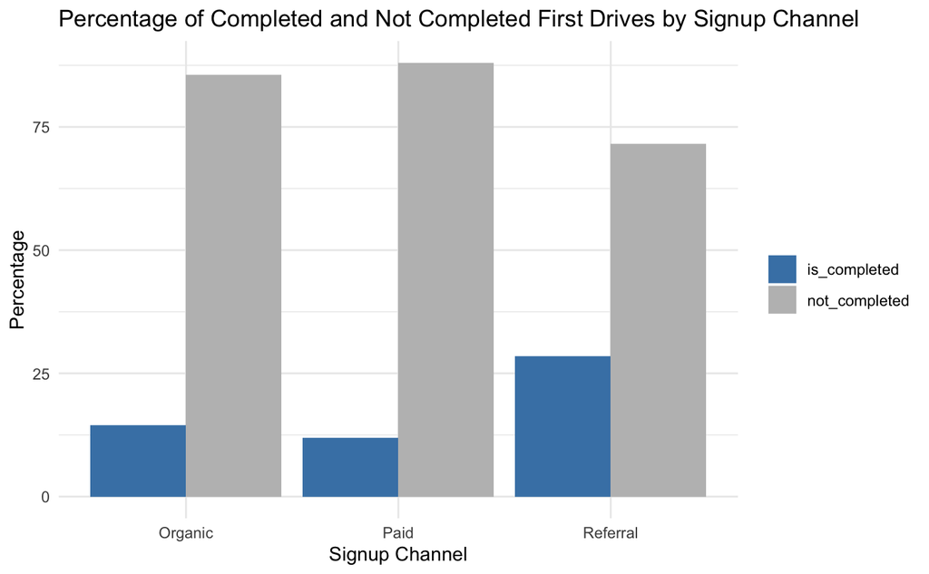

```r
# Group the data frame by 'singup_channel' and 'is_completed' and calculate the percentages
grouped <- aggregate(is_completed ~ signup_channel, data = uber_df, FUN = function(x) sum(x) / length(x) * 100)
grouped$not_completed <- 100 - grouped$is_completed

# Convert the data to long format
grouped_long <- tidyr::gather(grouped, key = Status, value = Percentage, is_completed, not_completed)
grouped_long$Status <- factor(grouped_long$Status, levels = c("is_completed", "not_completed"))

# Create the grouped bar chart
ggplot(grouped_long, aes(x = signup_channel, y = Percentage, fill = Status)) +
  geom_bar(stat = "identity", position = "dodge") +
  labs(title = "Percentage of Completed and Not Completed First Drives by Signup Channel", x = "Signup Channel", y = "Percentage") +
  scale_fill_manual(values = c("is_completed" = "steelblue", "not_completed" = "gray")) +
  theme_minimal() +
  theme(legend.title = element_blank())
```

Although most drivers signed up through Paid channels, drivers who signed up through Referral are more likely to complete their first drive. This can be useful information. The more signups Uber get by referrals, the more drivers they can produce which can increase revenue.

### **Chi-square test for Signup Device and First Drive Completion**

- **Null Hypothesis:** There is no relationship between Signup Device and First Drive Completion
- **Alternative Hypothesis:** There is a statistically significant relationship between Signup Device and First Drive Completion

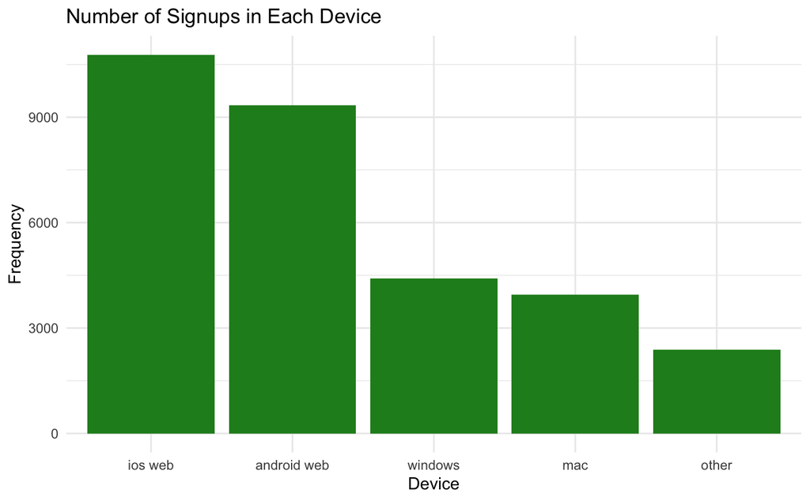

```r
# Count the number of drivers in each signup device
signup_os_counts <- table(uber_df$signup_os)

# Convert the driver counts to a data frame
signup_os_counts_df <- as.data.frame(signup_os_counts)

# Rename the columns in the driver counts data frame
names(signup_os_counts_df) <- c("Device", "Frequency")

# Sort the data in descending order
signup_os_counts_df <- signup_os_counts_df[order(signup_os_counts_df$Frequency, decreasing = TRUE), ]

# Create a bar graph
ggplot(signup_os_counts_df, aes(x = factor(Device, levels = Device), y = Frequency)) +
  geom_bar(stat = "identity", fill = "forestgreen") +
  labs(title = "Number of Signups in Each Device", x = "Device", y = "Frequency") +
  theme_minimal()
```

```r
# Create a contingency table
contingency <- table(uber_df$is_completed, uber_df$signup_os)
contingency
```

```
    android web ios web  mac other windows
  0        7886    8592 2997  1885    3519
  1        1454    2191  948   498     898
```

```r
# Perform the chi-square test
result <- chisq.test(contingency)
result
```

```
    Pearson's Chi-squared test

data:  contingency
X-squared = 153.51, df = 4, p-value < 2.2e-16
```

From Chi-square test, our p-value is less than 0.05, which means that there is a statistically significant relationship between signup device and completion first drive. Furthermore, from the aboved bar chart, most drivers are signed up on ios web. Thus, Uber should focus more on ios web to attract more drivers

### **What is the most popular type of vehicles for delivering ride-hailing service among registered new drivers ?**

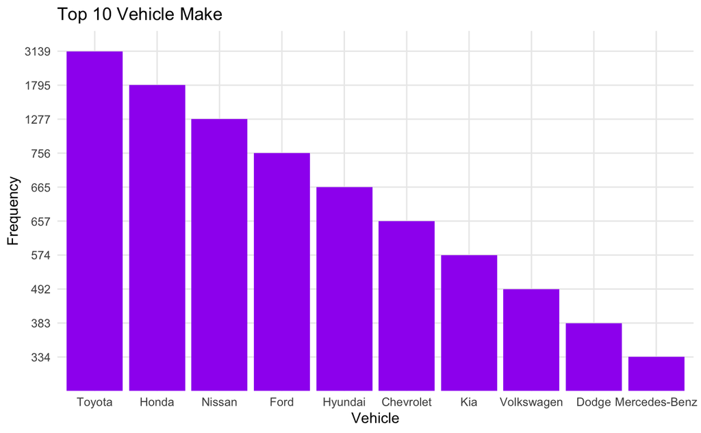

```r
# Count the number of signups in each vehicle make
vehicle_counts <- table(uber_df$vehicle_make)

# Convert the driver counts to a data frame
vehicle_counts_df <- as.data.frame(vehicle_counts)

# Rename the columns in the driver counts data frame
names(vehicle_counts_df) <- c("Vehicle", "Frequency")

# Sort the data in descending order
vehicle_counts_df <- vehicle_counts_df[order(vehicle_counts_df$Frequency, decreasing = TRUE), ]

# Select the top 10 values
top_10 <- vehicle_counts_df[1:10, ]
# Convert category to a factor with levels in the desired order
top_10$Frequency <- factor(top_10$Frequency, levels = rev(top_10$Frequency))

# Create a bar graph
ggplot(top_10, aes(x = factor(Vehicle, levels = Vehicle), y = Frequency)) +
  geom_bar(stat = "identity", fill = "purple") +
  labs(title = "Top 10 Vehicle Make", x = "Vehicle", y = "Frequency") +
  theme_minimal()
```

Tokyota and Honda are the 2 most popular vehicle brands for drivers to start their ride-hailing business

### **What is the percentage of drivers signing up became Uber drivers?**

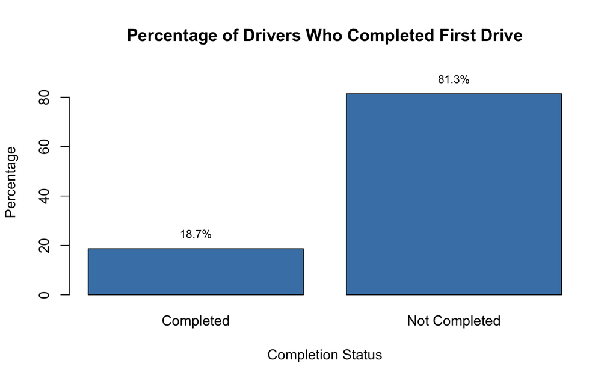

```r
# Calculate the percentage of drivers who completed and did not complete their first drive
completed_counts <- sum(uber_df$is_completed)
completed_pct <- completed_counts / nrow(uber_df) * 100
not_completed_pct <- 100 - completed_pct

# Create the bar chart
labels <- c("Completed", "Not Completed")
pcts <- c(completed_pct, not_completed_pct)

# Add percentage labels on top of each bar
text(x = barplot(pcts, ylim = c(0, max(pcts) + 10), names.arg = labels, xlab = "Completion Status",
                 ylab = "Percentage", main = "Percentage of Drivers Who Completed First Drive",col = "steelblue"),
     y = pcts + 1, labels = paste0(round(pcts, 1), "%"), pos = 3, cex = 0.8)
```

Only 18.7% of all sign-up drivers completed their first drivers. Thus, this dataset is highly imbalanced, we should be cautious when implementing predictive models

### **How the percentage of drivers completed each stage changes?**

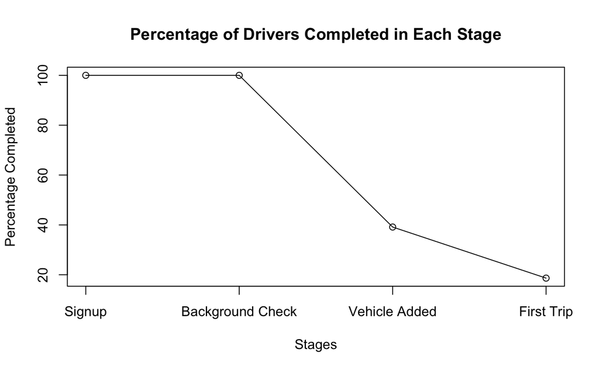

```r
# Calculate completion percentages for each stage
signup_percentage <- 100
bgc_percentage <- (sum(!is.na(uber_df$bgc_date)) / nrow(uber_df)) * 100
vehicle_percentage <- (sum(!is.na(uber_df$vehicle_added_date)) / nrow(uber_df)) * 100
first_trip_percentage <- (sum(!is.na(uber_df$first_completed_date)) / nrow(uber_df)) * 100

# Create the line plot
stages <- c("Signup", "Background Check", "Vehicle Added", "First Trip")
percentages <- c(signup_percentage, bgc_percentage, vehicle_percentage, first_trip_percentage)

plot(percentages, type = "o", xaxt = "n", xlab = "Stages", ylab = "Percentage Completed",
     main = "Percentage of Drivers Completed in Each Stage")

# Set x-axis labels
axis(1, at = 1:length(stages), labels = stages)
```

### **Distribution of days that took drivers to complete each stage**

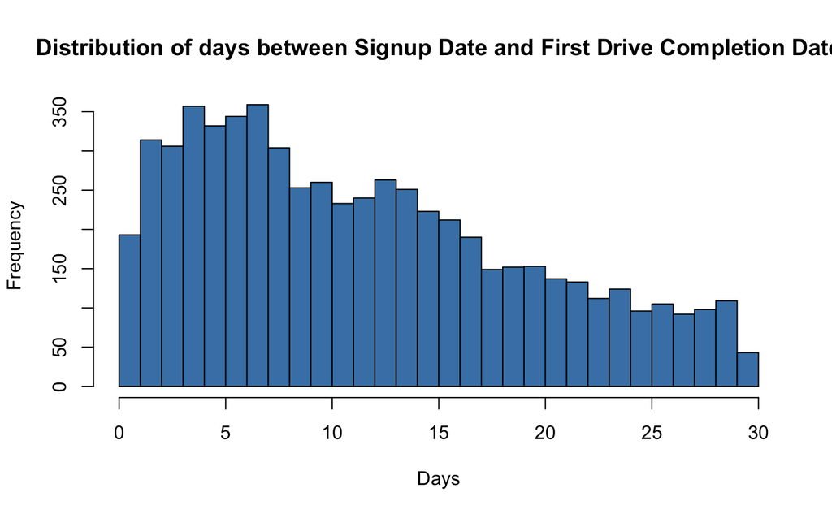

```r
# Filter the DataFrame to exclude NA values
filtered_df <- subset(uber_df, !is.na(signup_to_completed))

# Convert 'signup_to_completed' column to numeric
filtered_df$signup_to_completed <- as.numeric(as.character(filtered_df$signup_to_completed))

# Plot the distribution of the 'signup_to_completed' column
hist(filtered_df$signup_to_completed, breaks = "FD", col = "steelblue", border = "black",
     xlab = "Days", ylab = "Frequency",
     main = "Distribution of days between Signup Date and First Drive Completion Date")
```

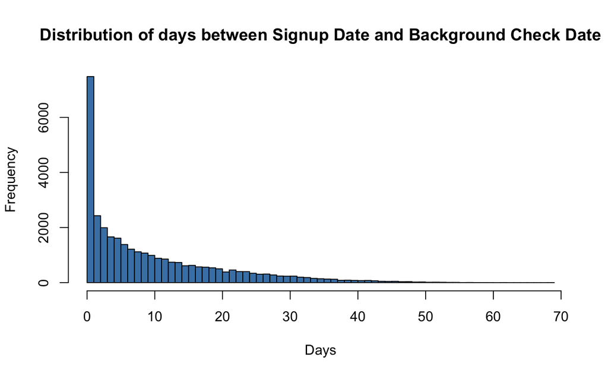

```r
# Filter the DataFrame to exclude NA values
filtered_df <- subset(uber_df, !is.na(signup_to_bgc))

# Convert 'signup_to_bgc' column to numeric
filtered_df$signup_to_bgc <- as.numeric(as.character(filtered_df$signup_to_bgc))

# Plot the distribution of the 'signup_to_bgc' column
hist(filtered_df$signup_to_bgc, breaks = "FD", col = "steelblue", border = "black",
     xlab = "Days", ylab = "Frequency",
     main = "Distribution of days between Signup Date and Background Check Date")
```

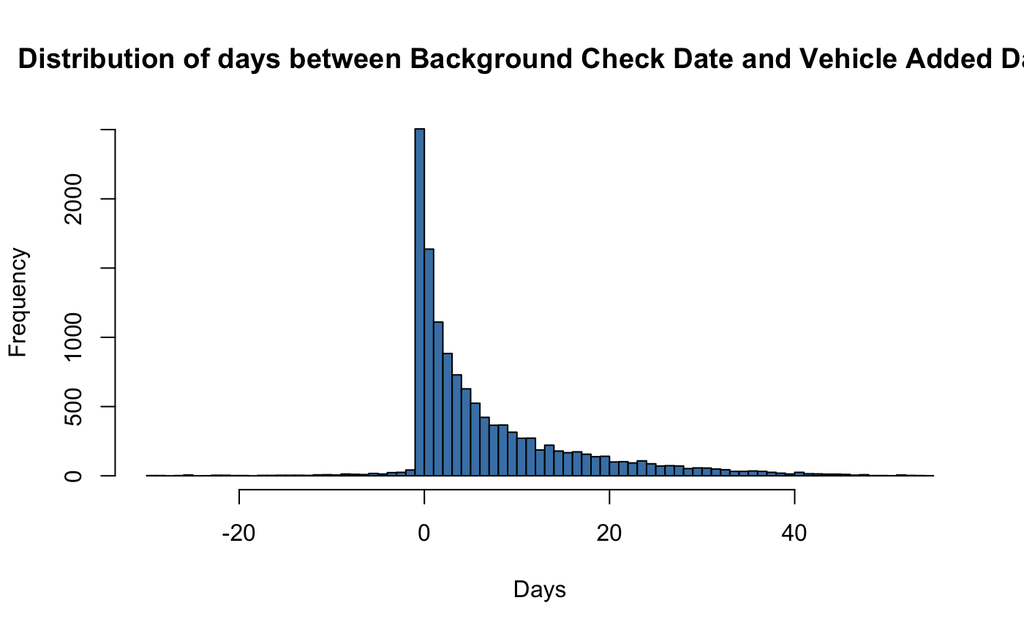

```r
# Filter the DataFrame to exclude NA values
filtered_df <- subset(uber_df, !is.na(bgc_to_vehicle))

# Convert 'bgc_to_vehicle' column to numeric
filtered_df$bgc_to_vehicle <- as.numeric(as.character(filtered_df$bgc_to_vehicle))

# Plot the distribution of the 'signup_to_bgc' column
hist(filtered_df$bgc_to_vehicle, breaks = "FD", col = "steelblue", border = "black",
     xlab = "Days", ylab = "Frequency",
     main = "Distribution of days between Background Check Date and Vehicle Added Date")
```